# Quiz 1: Part 2

## Part 2: Coding in action

### Instructions

Please answer these questions in R using whatever syntax makes sense to you. Feel free to use the R help pages and/or notes from class.

**If you use Google or ChatGPT etc. to help you get to an answer, please note so on your answer**

Step 1. ARE YOU IN A BRANCH?????  
Step 2. Save this file as lastname_quiz.qmd in the same quiz folder.  
Step 3. Once you are done, click “render” above. This will create the .html file that I will evaluate.  
Step 4. Stage and commit your changes, push to your github.  
Step 5. Submit a pull request. If github warns you of conflicts please try and fix them before submitting your pull request (did you rename the file??? ).  
(Step 6. In case of utter disaster, email Sabrina your .html file.)

```r
# load packages and data
library(ggplot2)
library(dslabs)
library(dplyr)
```

#### Load your data:

Load the *swallows.csv* into R, call it swallows. This data frame lists results of an experiment on tree swallows. Each row is a nest. Nests were put into one of two **treatments**: simulated predation (predator), or control (control). Along with treatment you have the following columns:  
**nest_fate** = whether the nest fledged any young or whether they all died  
**brood** = number of nestlings  
**n_fledged** = number of nestlings that fledged.

You also have a separate data frame called *brightness.csv* where each row lists the plumage brightness (a sexual signal) for the female at each nest. Load this one up too.

```r
# Type your answer in this box using R code
library(ggplot2)
library(dslabs)
library(dplyr)

setwd('C:/Users/DUGGA/OneDrive/Desktop/Ari/ECOL_596W_2025-ari/quiz')
swallows <- read.csv("swallows.csv")
brightness <- read.csv("brightness.csv")
# I know I shouldn't set the wd in here, but RStudio could not render the html file for me if I did not set the wd in these lines.

# Google? y/n
# No.
```

#### Wrangle your data

```r
#Answer
swalbright <- merge(swallows, brightness, by = 'nestbox')
#To check this worked as intended, I went back to the original data frames and made sure that the brightness values in the brightness dataframe matched their brood and n_fledged values in the swallows dataframe. I did this for five birds.

#Google?
#Yes, but just for the merge command. From there I just used the help section in RStudio to use the "by" command.
```

Inspect your combined data frame. Do some sort of quick sanity check on each column to catch any obvious entry errors. Correct as necessary

```r
# Answer
swalbrightgood <- swalbright |> filter(brightness != 'NA')
# I just removed the row with an "NA" value for brightness. I also checked that no observation had more fledged chicks than chicks.

# Google y/n
# No
```

Create a new column called prop_fledged that contains the proportion of nestlings that fledged from each nest.

```r
#Answer
swal10 <- swalbrightgood |> mutate(prop_fledged = n_fledged/brood) |> filter(brood != 0)
# Here I am taking out all the observations where the brood was 0 because obviously if there are no chicks there are no fledglings. Having n_fledged/brood also gives us NaN values, which mess up the graphs for the last two questions.

# Google? y/n
# No
```

#### Explore the data

What was the mean proportion of nestlings fledged in each treatment?

```r
# Answer
swal11 <- swal10 |> group_by(treatment) |> summarize(mean = mean(prop_fledged, na.rm = T))
# Needed to take out NAs to not mess up the mean calculation.

# Google? y/n
# Yes, just a small check of summarise syntax. Could have used help section in RStudio.
```

Create a plot showing fledging success differences between treatments

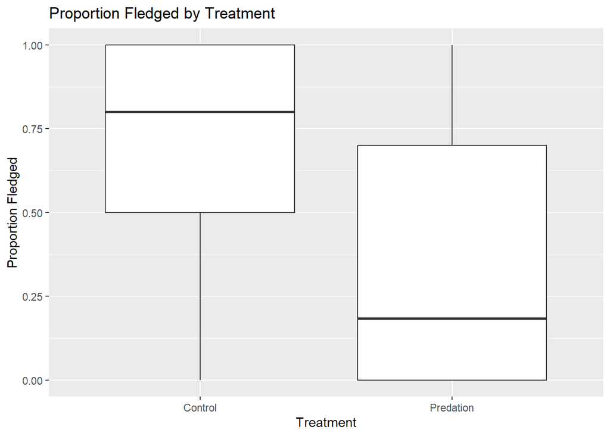

```r
# Answer
ggplot(swal10, aes(treatment, prop_fledged)) + geom_boxplot() + labs(x = 'Treatment', y = 'Proportion Fledged', title = 'Proportion Fledged by Treatment')
```

```r
# Google? y/n
# Yes, just for labels
```

Is there any evidence that female brightness influenced fledging success? Create a plot to visually investigate this question.

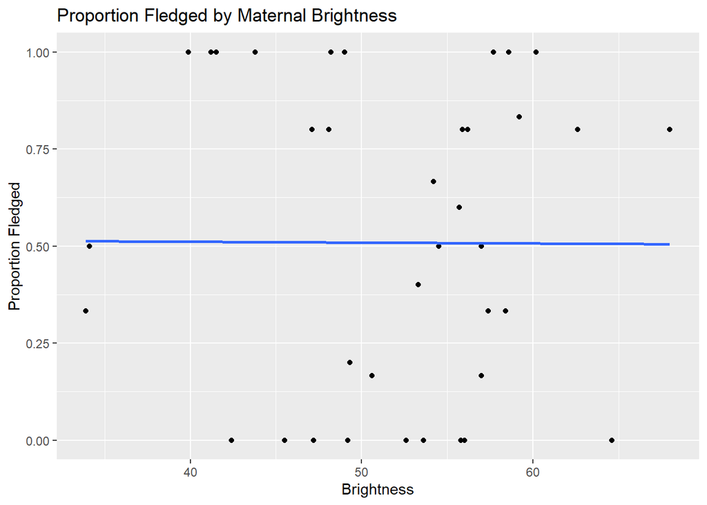

```r
# Answer
ggplot(swal10, aes(brightness, prop_fledged)) + geom_point() + labs(x = 'Brightness', y = 'Proportion Fledged', title = 'Proportion Fledged by Maternal Brightness') + geom_smooth(method=lm, se=FALSE)
```

```r
#There does not seem to be any relationship between maternal brightness and fledging success. The line-of-best-fit that R gives is almost completely flat, so we can not say from this dataset that there is a relationship between female plumage brightness and fledging success.

# Google? y/n
# Yes, for the line-of-best-fit.
```